# Lecture 4: Boleean variables and if/else statements

In the previous class we:

- Introduced numeric lists and random numbers
- Talked about mathematical operations

In this class we will:

- Introduce bolean types
- Test different categories of expressions with text and numbers
- Study if/else statements

## I. Import Libraries

```python
# the "numPy" library is used for mathematical operations
# the "matplotlib" library is for generating graphs

import numpy as np
import matplotlib.pyplot as plt
```

## II. Testing Expressions with Text

- Sometimes need to know whether some expression is `True` or `False`
- In Python this is called a **Boolean** type

Test equality of strings (==)

```python
# You can compare two strings by using a double "equal sign"
# This can be useful if you're trying to evaluate whether data was entered correctly

"Is this the real life?" == "is this just fantasy?"

# Note: This is a reference to the famous Queen song "Bohemian Rhapsody"!
```

```
False
```

```python
# Equality of strings is most useful when you're comparing an unknown variable
# to a benchmark.

# Below, try switching the value of "any_questions"

any_questions = "no"

print( any_questions == "yes" )
```

```
False
```

Test for the presence of keywords in a sentence (in)

```python
# The first way to use the "in" command is to check whether a word is contained
# in a sentence. This can be useful if you're trying to search for patterns

keyword = "econ"
sentence = "The Federal Reserve makes forecasts about many economic outcomes"

keyword in sentence

# Try changing the keyword!
```

```
True
```

Test whether a word is part of a list (in)

```python
# There is a second way to use the "in" command
# Use the condition "in" to test whether a word is part of a list
# when the right-han size is a list "word in list" will search for an exact match

current_month      = "January"
list_summer_months = ["June","July","August"]

print( current_month in list_summer_months)
```

```
False
```

Common Pitfall: Single vs double equality

```python
# A single vs double equality sign makes a BIG difference
# When you have a single equality (=) you are assignning the variable
# When you have a double equality (==) you are comparing two values

message_hello = "hello"

print( message_hello == "hello" )
```

```
True
```

Try it yourself!

Write code to check whether the string "red" is contained in the list

["red","green","yellow","orange"]

```python
# Write down your solution!
```

## III. Testing Expressions with Numbers

Tests with numbers

- Strictly less than (<), less than or equal (<=)
- Equal (==)
- Strictly more than (>), greater than or equal to (>=)

```python
# We can check equality and inequality constraints
# Try changing $x$ and see what happens!

x = 5

print( x < 5 )
print( x <= 5 )
print( x == 5 )
print( x >= 5 )
print( x > 5 )
```

```
False
True
True
True
False
```

Validate a data type

```python
# The isinstance command

y = 10

print( isinstance(y,int)  )
print( isinstance(y,float) )
print( isinstance(y,str) )

## Common pitall:
## Doing type(y) == "int" will NOT produce the right answer.
```

```
True
False
False
```

Common Pitfall: Equality of vectors is done element-by-element

```python
vec_a = np.array([1,2,3])
vec_b = np.array([1,2,4])

vec_a == vec_b
```

```
array([ True,  True, False])
```

Try it yourself!

- Check whether $e^5$ < 50
- Define $ x= -1$. Check whether $x^2 + 2x + 1 = 0$.

```python
# Write down your own solution
```

## IV. Testing Multiple Expressions

not Condition A: prefix "not"

```python
age  = 22

# Can this person legally vote in the US?
not (age < 18)

# Note: This expression evaluates whether a person
# is not underage

# The "not" word can be separated by a space and the parentheses are not necessary
# but the parentheses can be helpful to organize your code logically
```

```
True
```

Condition A and Condition B need to be satisfied: &

```python
# We use the "&" symbol to separate "AND" conditions
age = 5

# Is this age between 20 and 30 (including these ages)?
( age >= 20 ) & (age <= 30)
```

```
False
```

Condition A or Condition B need to be satisfied: |

```python
# We use the "|" symbol to separate "OR" conditions.

student_status = "freshman"

# Is the student in the first two years of undergrad?
(student_status == "freshman") | (student_status == "sophomore")
```

```
True
```

Try it yourself! Write code that checks the following conditions:

- Whether age is strictly less than 20, or greater than 30
- Not in the age range 25-27

```python
# Write your own code
```

## IV. Flow Control (if/elif/else)

Why?

- Adapt the code to different logical conditions
- We'll use these ideas again for data cleaning!

[figure not shown]

Running a part of the code  
only if a condition is met:

```
if test_expression:
        Body
```

```python
#------------------------------------------------------------------------------#
#--------------------------- EXPLANATION OF IF SYNTAX -------------------------#
#
# Test expression
#---- We type "if" followed by a logical condition and the ":" symbol.
#---- The ":" says: run the following command
#
# Body of expression
#---- The "body" of the "if" statement needs to indented
#---- You can indent text by pressing the "tab" button in your keyborad.
#
# If the condition is true, a message will appear.
# If the condition is false, then nothing happens
#------------------------------------------------------------------------------#


# We start by defining a string
any_questions = "yes"

if any_questions == "yes":
    print("Need to give more explanations")
```

```
Need to give more explanations
```

[figure not shown]

Running two different lines of code  
depending on a condition

```
if test_expression:
        Body
    else:
        Body
```

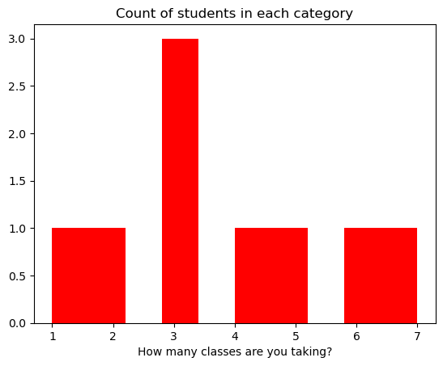

```python
#------------------------------------------------------------------------------#
#--------------------------- EXPLANATION OF IF/ELSE SYNTAX --------------------#
#
# If/else statements are useful to run different types of commands
# depending on a user-specified input
#
# This code prints a red graph if "is_red_graph" is set to "True"
# and outputs a purple graph otherwise.
#
# Notation: You can use the prefix "is_" to denote boleean variables
#
# VIEWING OUTPUT:
# You can guarantee that the graph appears with plt.show()
#------------------------------------------------------------------------------#


is_graph_red     = True
how_many_classes = np.array([7,1,2,3,3,3,4,5,6])

if is_graph_red:
    plt.hist(x = how_many_classes, color="red")
    plt.title("Count of students in each category")
    plt.xlabel("How many classes are you taking?")
    plt.show()
else:
    plt.hist(x = how_many_classes, color="purple")
    plt.title("Count of students in each category")
    plt.xlabel("How many classes are you taking?")
    plt.show()
```

What happens if ... ? Try the following:

- Rerun the above code but change the value of "is_graph_red".
- What happens if you set a non-boolean value of "is_graph_red"?
- Don't include ":"
- Don't indent the body of the "if"

[figure not shown]

Running multiple different lines of code  
depending on a series of conditions

```
if test_expression:
        Body
    elif test_expression:
        Body
    else:
        Body
```

```python
# The elif (a shorthand for elif) is a good alternative to evaluate
# mutually exclusive options

years_in_program = 1

if years_in_program == 1:
    print("This student is a freshman")
elif years_in_program == 2:
    print("This student is a sophomore")
elif years_in_program == 3:
    print("This student is a junior")
else:
    print("This student is a senior")



# Try changing the initial input
```

```
This student is a freshman
```

## V. Exercises

Try it yourself!

- Create a variable called "points" with a value between 0 and 100
- Write a flow with "if", "elif" and "else" to assign the letter grade
- In the body, store the output in a new variable called "letter_grade"
- Print the letter grade at the end

[figure not shown]

Important: Check that it works by trying different values of "points"!

```python
# Write down your solution to this problem
```

Try it yourself!

- Create a numeric vector, $ c = \begin{bmatrix} 1 \\ 2 \\ 3 \end{bmatrix} $
- Use the "sum()"' function to add up the individual elements.
- If the sum of numbers is higher than $5$, write a message saying

" The sum is greater than or equal to 5"

- Otherwise show a message "It is strictly less than 5"

```python
# Write down your solution to this problem
```